# Session 9

Maria Prokofieva

18/05/2021

# Decision Trees

A decision tree is a decision support tool that uses a tree-like model of decisions and their possible consequences, including chance event outcomes, resource costs, and utility. It is one way to display an algorithm that only contains conditional control statements.

Decision trees can be learned from training data. Training data will typically comprise many instances of the following kind:

Instance 1 attribute1 attribute2 … attributeK class Instance 2 attribute1 attribute2 … attributeK class The decision tree learning algorithm recursively learns the tree as follows:

Assign all training instances to the root of the tree. Set curent node to root node.

For each attribute

- Partition all data instances at the node by the value of the attribute.
- Compute the information gain ratio from the partitioning.
- Identify feature that results in the greatest information gain ratio. Set this feature to be the splitting criterion at the current node.
- If the best information gain ratio is 0, tag the current node as a leaf and return.
- Partition all instances according to attribute value of the best feature.
- Denote each partition as a child node of the current node.
- For each child node:

-If the child node is “pure” (has instances from only one class) tag it as a leaf and return.

-If not set the child node as the current node and recurse to step 2.

## Load the weekly Data

```r
ikea <-readr::read_csv('https://raw.githubusercontent.com/rfordatascience/tidytuesday/master/data/2020/2020-11-03/ikea.csv') %>%
  select(-X1) %>%
  mutate(price_usd = 0.27 * price,
         short_description = str_squish(short_description)) %>%
  add_count(category, name = "category_total")
```

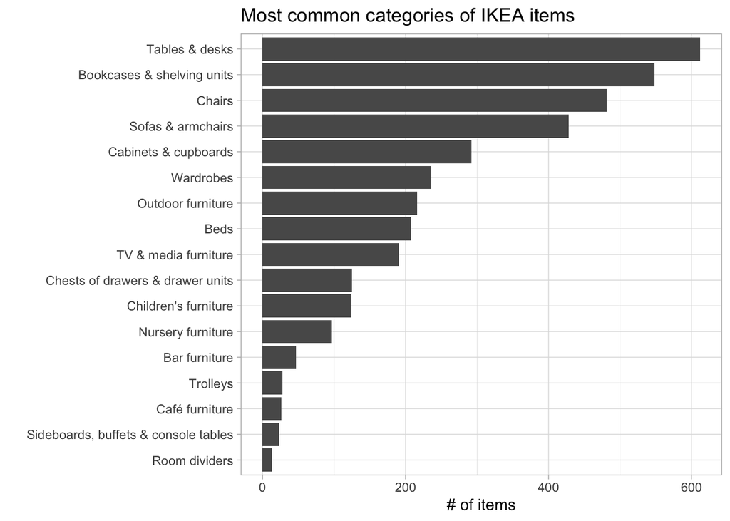

```r
ikea %>%
  count(category, sort = TRUE) %>%
  mutate(category = fct_reorder(category, n)) %>%
  ggplot(aes(n, category)) +
  geom_col() +
  labs(x = "# of items",
       y = "",
       title = "Most common categories of IKEA items")
```

```r
library(glue)
```

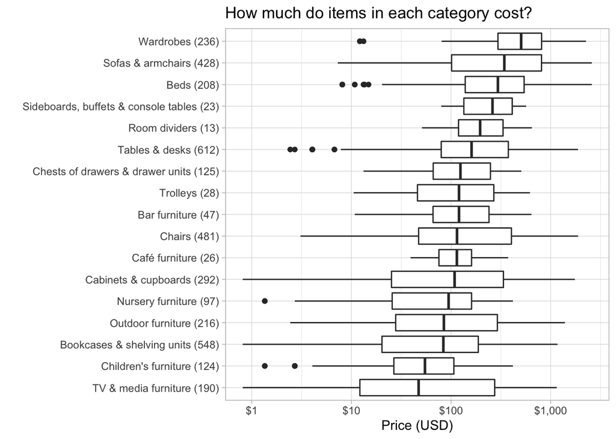

```r
ikea %>%
  mutate(category = glue("{ category } ({ category_total })"),
         category = fct_reorder(category, price_usd)) %>%
  ggplot(aes(price_usd, category)) +
  geom_boxplot() +
  # geom_jitter(width = 0, height = .1, alpha = .25) +
  scale_x_log10(labels = dollar) +
  labs(x = "Price (USD)",
       y = "",
       title = "How much do items in each category cost?")
```

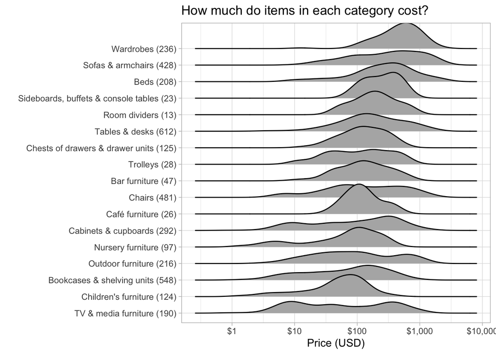

```r
library(ggridges)
ikea %>%
  mutate(category = glue("{ category } ({ category_total })"),
         category = fct_reorder(category, price_usd)) %>%
  ggplot(aes(price_usd, category)) +
  geom_density_ridges() +
  # geom_jitter(width = 0, height = .1, alpha = .25) +
  scale_x_log10(labels = dollar) +
  labs(x = "Price (USD)",
       y = "",
       title = "How much do items in each category cost?")
```

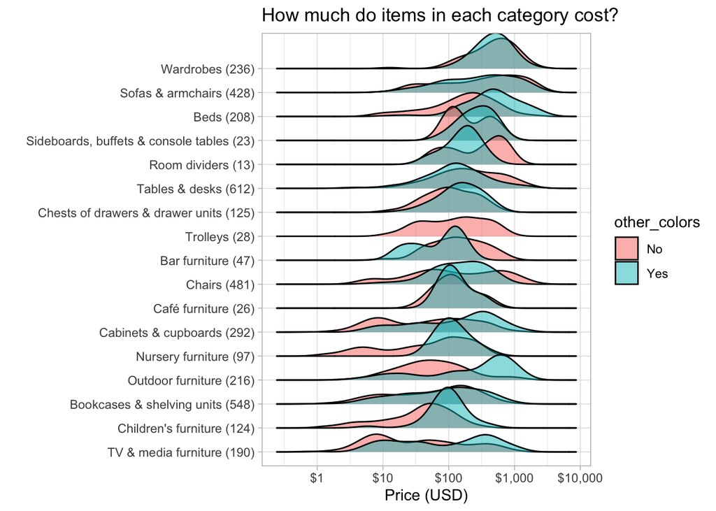

```r
ikea %>%
  mutate(category = glue("{ category } ({ category_total })"),
         category = fct_reorder(category, price_usd)) %>%
  ggplot(aes(price_usd, category, fill = other_colors)) +
  geom_density_ridges(alpha = .5) +
  # geom_jitter(width = 0, height = .1, alpha = .25) +
  scale_x_log10(labels = dollar) +
  labs(x = "Price (USD)",
       y = "",
       title = "How much do items in each category cost?")
```

If we were building a predictive model, we’d probably include both category and other_colors

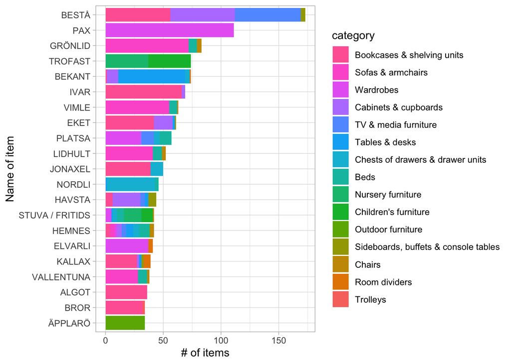

```r
ikea %>%
  mutate(name = fct_lump(name, 20)) %>%
  filter(name != "Other") %>%
  count(name, category, sort = TRUE) %>%
  mutate(name = fct_reorder(name, n, sum),
         category = fct_reorder(category, n, sum)) %>%
  ggplot(aes(n, name, fill = category)) +
  geom_col() +
  scale_fill_discrete(guide = guide_legend(reverse = TRUE)) +
  labs(x = "# of items",
       y = "Name of item")
```

```r
ikea %>%
  separate(short_description,
           c("main_description", "rest"),
           sep = ", ",
           extra = "merge",
           fill = "right",
           remove = FALSE) %>%
  extract(rest, "description_cm", "([\\d\\-xX]+) cm", remove = FALSE) %>%
  unite(category_and_description, category, main_description, sep = " - ") %>%
  count(category_and_description, sort = TRUE)
```

```
## # A tibble: 1,012 x 2
##    category_and_description                       n
##    <chr>                                      <int>
##  1 Tables & desks - Table                       127
##  2 Wardrobes - Wardrobe                         121
##  3 Chairs - Table and 4 chairs                   83
##  4 Tables & desks - Table and 4 chairs           83
##  5 Chairs - Chair                                53
##  6 Bookcases & shelving units - Shelving unit    45
##  7 Chairs - Table and 6 chairs                   39
##  8 Tables & desks - Table and 6 chairs           39
##  9 Sofas & armchairs - Corner sofa               33
## 10 Sofas & armchairs - 3-seat sofa               32
## # … with 1,002 more rows
```

### Volume

```r
ikea_volume <- ikea %>%
  mutate(volume_m3 = depth * height * width / 1e6) %>%
  filter(!is.na(volume_m3),
         volume_m3 >= .001) %>%
  arrange(desc(volume_m3)) %>%
  add_count(category, name = "category_total")
ikea_volume %>%
  arrange(desc(volume_m3))
```

```
## # A tibble: 1,891 x 16
##     item_id name  category price old_price sellable_online link     other_colors
##       <dbl> <chr> <chr>    <dbl> <chr>     <lgl>           <chr>    <chr>
##  1 19300107 PAX   Wardrob…  5380 No old p… TRUE            https:/… No
##  2 69254810 GRÖN… Sofas &…  6575 No old p… TRUE            https:/… Yes
##  3 89256610 GRÖN… Sofas &…  8900 No old p… TRUE            https:/… No
##  4 59193723 KIVIK Sofas &…  8295 No old p… TRUE            https:/… Yes
##  5 49252949 KIVIK Sofas &…  6895 No old p… TRUE            https:/… Yes
##  6 69285294 VIMLE Sofas &…  8395 No old p… TRUE            https:/… Yes
##  7 29277639 LIDH… Beds      9585 No old p… TRUE            https:/… Yes
##  8 79277632 LIDH… Sofas &…  9585 No old p… TRUE            https:/… Yes
##  9 69257328 LIDH… Sofas &…  6295 No old p… TRUE            https:/… Yes
## 10 49257348 LIDH… Sofas &…  7748 SR 9,685  TRUE            https:/… No
## # … with 1,881 more rows, and 8 more variables: short_description <chr>,
## #   designer <chr>, depth <dbl>, height <dbl>, width <dbl>, price_usd <dbl>,
## #   category_total <int>, volume_m3 <dbl>
```

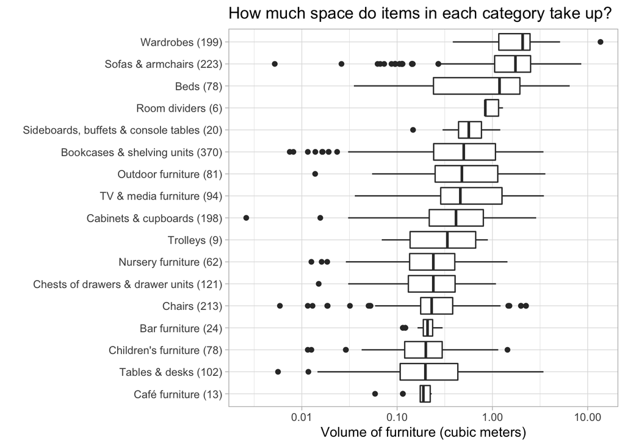

```r
ikea_volume %>%
  mutate(category = glue("{ category } ({ category_total })"),
         category = fct_reorder(category, volume_m3)) %>%
  ggplot(aes(volume_m3, category)) +
  geom_boxplot() +
  # geom_jitter(width = 0, height = .1, alpha = .25) +
  scale_x_log10() +
  labs(x = "Volume of furniture (cubic meters)",
       y = "",
       title = "How much space do items in each category take up?")
```

What is the highest “price per cubic meter”?

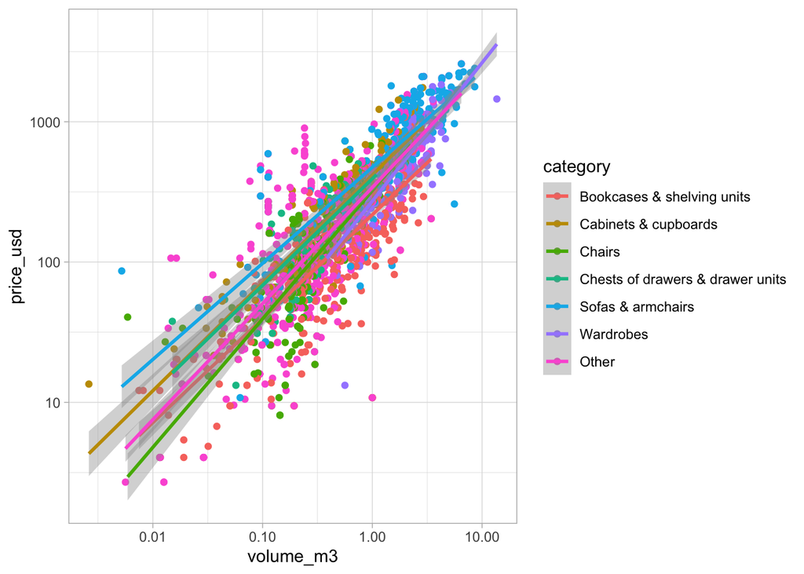

```r
ikea_volume %>%
  mutate(category = fct_lump(category, 6)) %>%
  ggplot(aes(volume_m3, price_usd, color = category)) +
  geom_point() +
  geom_smooth(method = "lm") +
  scale_x_log10() +
  scale_y_log10()
```

```r
ikea_volume %>%
  mutate(dollar_per_m3 = price_usd / volume_m3) %>%
  arrange(desc(dollar_per_m3)) %>%
  View()
```

```r
ikea %>%
  group_by(designer) %>%
  summarize(n_items = n(),
            n_names = n_distinct(name),
            n_category = n_distinct(category)) %>%
  arrange(desc(n_names))
```

```
## # A tibble: 381 x 4
##    designer                       n_items n_names n_category
##    <chr>                            <int>   <int>      <int>
##  1 IKEA of Sweden                     828     167         17
##  2 K Hagberg/M Hagberg                122      30         14
##  3 Ola Wihlborg                       134      24         10
##  4 Jon Karlsson                       120      17         10
##  5 Ebba Strandmark                     57      15         11
##  6 Francis Cayouette                  151      15          7
##  7 IKEA of Sweden/Ehlén Johansson      70      14          5
##  8 Ehlén Johansson                    161      13          8
##  9 Henrik Preutz                       70      13         11
## 10 Nike Karlsson                       53      12          9
## # … with 371 more rows
```

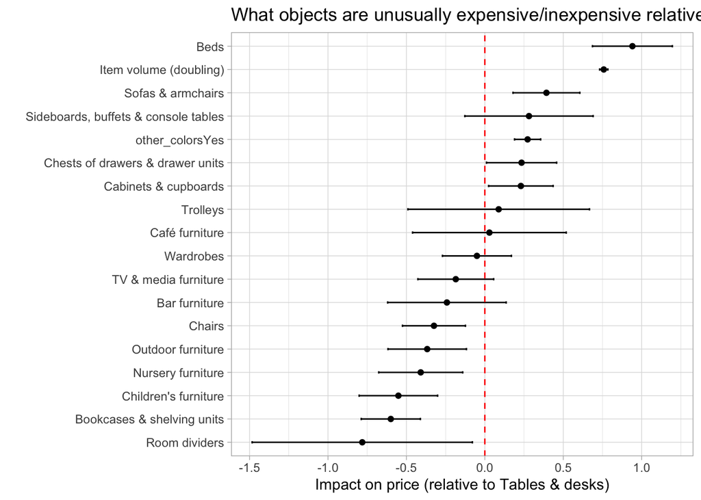

```r
library(broom)
ikea_volume %>%
  mutate(category = fct_relevel(category, "Tables & desks")) %>%
  lm(log2(price_usd) ~ log2(volume_m3) + category + other_colors, data = .) %>%
  tidy(conf.int = TRUE) %>%
  filter(term != "(Intercept)") %>%
  mutate(term = ifelse(term == "log2(volume_m3)", "Item volume (doubling)", term),
         term = str_remove(term, "^category")) %>%
  mutate(term = fct_reorder(term, estimate)) %>%
  ggplot(aes(estimate, term)) +
  geom_point() +
  geom_errorbarh(aes(xmin = conf.low, xmax = conf.high), height = .1) +
  geom_vline(xintercept = 0, color = "red", lty = 2) +
  labs(x = "Impact on price (relative to Tables & desks)",
       y = "",
       title = "What objects are unusually expensive/inexpensive relative to volume?")
```